# Renal Clear Cell Carcinoma Machine Learning Project

# Pre-liminary Conclusions from Clinical Data

# Primary Tumor Renal Clear Cell Carcinoma RNA-Seq Data

# Pre-Processing

- The pre-pre-processing is in the separate notebook, 'RNA Seq data.ipynb'
  - What resulted was the FPKM values for RNA-Seq of primary tumor tissue associated to the 'submitter_id' variable, which is a unique ID for each patient
- Further normalization was done on the resulting FPKM data

```python
from sklearn.preprocessing import normalize
from sklearn.model_selection import RepeatedStratifiedKFold
from sklearn.linear_model import LogisticRegression
from sklearn.svm import SVC
from sklearn.ensemble import RandomForestClassifier

# Import data
tumor = pd.read_csv("~/Desktop/Academics/stash/Primary_Tumor_FPKM.csv", index_col = 0)
normal = pd.read_csv("~/Desktop/Academics/stash/Solid_Tumor_FPKM.csv", index_col = 0)

# Combine Data into one frame
allData = tumor.append(normal)
allData.head()
```

|  | ENSG00000242268.2 | ENSG00000270112.3 | ENSG00000167578.15 | ENSG00000078237.5 | ENSG00000146083.10 | ENSG00000158486.12 | ENSG00000198242.12 | ENSG00000259883.1 | ENSG00000231981.3 | ENSG00000134108.11 | ... | ENSG00000272515.1 | ENSG00000009694.12 | ENSG00000186115.11 | ENSG00000216352.1 | ENSG00000267117.1 | ENSG00000273233.1 | ENSG00000105063.17 | ENSG00000231119.2 | ENSG00000123685.7 | ENSG00000181518.3 |
| --- | --- | --- | --- | --- | --- | --- | --- | --- | --- | --- | --- | --- | --- | --- | --- | --- | --- | --- | --- | --- | --- |
| TCGA-B2-4098 | 17617.224082 | 128.655041 | 63040.284079 | 118686.297308 | 352310.079395 | 836.111571 | 2.397861e+06 | 853.862318 | 0.000000 | 932447.020809 | ... | 5453.016807 | 9341.966195 | 7333.378311 | 0.0 | 5971.227640 | 3090.741067 | 324813.739621 | 7278.362048 | 9948.928027 | 0.0 |
| TCGA-B0-4846 | 4899.385005 | 203.941568 | 51423.009186 | 89639.459221 | 242946.306285 | 651.068007 | 1.981451e+06 | 6316.457451 | 477.169184 | 660888.127029 | ... | 785.820035 | 67380.980588 | 332.135266 | 0.0 | 3155.159504 | 816.564167 | 228434.290999 | 961.460297 | 33593.203044 | 0.0 |
| TCGA-CZ-5458 | 2325.711202 | 193.619889 | 48988.208941 | 51454.917845 | 261341.729255 | 927.175241 | 3.754032e+06 | 7281.798758 | 453.019192 | 368022.986060 | ... | 0.000000 | 36031.571339 | 315.325580 | 0.0 | 0.000000 | 2325.711202 | 249180.718680 | 8945.438666 | 14972.676691 | 0.0 |
| TCGA-BP-5006 | 2703.576494 | 62.521637 | 58263.893221 | 96516.697058 | 278095.801177 | 278.008144 | 4.283618e+06 | 6224.187129 | 0.000000 | 389257.808551 | ... | 0.000000 | 33664.377125 | 1018.215208 | 0.0 | 1450.898950 | 2252.980411 | 203092.682638 | 4951.824276 | 92804.855475 | 0.0 |
| TCGA-B8-A54D | 16495.368608 | 352.120735 | 110295.716087 | 66755.475290 | 414637.252093 | 301.103242 | 1.463964e+06 | 3505.450976 | 0.000000 | 421478.525505 | ... | 0.000000 | 485938.792390 | 860.185456 | 0.0 | 4085.718371 | 0.000000 | 357869.642390 | 3984.083586 | 33538.883520 | 0.0 |

5 rows × 52677 columns

```python
# make y labels for dataset
# note: 0 = Tumor, 1 = Normal
labels = pd.Series(["Primary Tumor", "Normal Tumor"]).repeat([530, 72])
y = pd.Series([0, 1]).repeat([530, 72])
print(labels[0:10])
```

```
0    Primary Tumor
0    Primary Tumor
0    Primary Tumor
0    Primary Tumor
0    Primary Tumor
0    Primary Tumor
0    Primary Tumor
0    Primary Tumor
0    Primary Tumor
0    Primary Tumor
dtype: object
```

```python
# normalize data
allData_norm = normalize(allData, axis = 0)
allData_normDF = pd.DataFrame(allData_norm)
allData_normDF.head()
```

|  | 0 | 1 | 2 | 3 | 4 | 5 | 6 | 7 | 8 | 9 | ... | 52667 | 52668 | 52669 | 52670 | 52671 | 52672 | 52673 | 52674 | 52675 | 52676 |
| --- | --- | --- | --- | --- | --- | --- | --- | --- | --- | --- | --- | --- | --- | --- | --- | --- | --- | --- | --- | --- | --- |
| 0 | 0.083628 | 0.000878 | 0.030993 | 0.055679 | 0.046999 | 0.011280 | 0.025755 | 0.003630 | 0.000000 | 0.066818 | ... | 0.024576 | 0.006112 | 0.001649 | 0.0 | 0.005919 | 0.056212 | 0.045810 | 0.031052 | 0.009059 | 0.0 |
| 1 | 0.023257 | 0.001391 | 0.025282 | 0.042052 | 0.032410 | 0.008783 | 0.021282 | 0.026857 | 0.005932 | 0.047358 | ... | 0.003542 | 0.044082 | 0.000075 | 0.0 | 0.003128 | 0.014851 | 0.032217 | 0.004102 | 0.030589 | 0.0 |
| 2 | 0.011040 | 0.001321 | 0.024085 | 0.024139 | 0.034864 | 0.012508 | 0.040322 | 0.030961 | 0.005632 | 0.026372 | ... | 0.000000 | 0.023573 | 0.000071 | 0.0 | 0.000000 | 0.042298 | 0.035143 | 0.038164 | 0.013634 | 0.0 |
| 3 | 0.012834 | 0.000427 | 0.028645 | 0.045278 | 0.037099 | 0.003750 | 0.046010 | 0.026464 | 0.000000 | 0.027894 | ... | 0.000000 | 0.022024 | 0.000229 | 0.0 | 0.001438 | 0.040975 | 0.028643 | 0.021126 | 0.084505 | 0.0 |
| 4 | 0.078303 | 0.002402 | 0.054226 | 0.031317 | 0.055313 | 0.004062 | 0.015724 | 0.014905 | 0.000000 | 0.030203 | ... | 0.000000 | 0.317912 | 0.000193 | 0.0 | 0.004050 | 0.000000 | 0.050473 | 0.016997 | 0.030539 | 0.0 |

5 rows × 52677 columns

# Principle Component Analysis

```
<function matplotlib.pyplot.show(*args, **kw)>
```

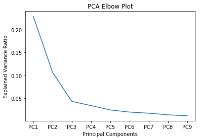

```python
# PCA
pca = PCA(n_components = 9)
pca.fit(allData_norm)
variance = pca.explained_variance_ratio_
PC = ['PC1', 'PC2', 'PC3', 'PC4', 'PC5', 'PC6', 'PC7', 'PC8', 'PC9']

#PCA Elbow Plot
sb.lineplot(PC, variance)
plt.title("PCA Elbow Plot")
plt.xlabel("Principal Components")
plt.ylabel("Explained Variance Ratio")
plt.show
```

```python
# hard to tell where elbow is, but 4 was selected
# run pca with 4 components to make new data set
pca = PCA(n_components = 4)
allData_pca = pca.fit_transform(allData_norm)
allData_pca.shape
```

```
(602, 4)
```

# Preparing/Splitting data for model training

```python
# finally, define input for classification models
X = allData_pca
# y is defined above

# stratify data to train/test model
X_train, X_test, y_train, y_test = train_test_split(X, y, test_size = 0.2, stratify=y, random_state=42)

# define cross validation method
cv = RepeatedStratifiedKFold(n_splits=5,n_repeats=1000, random_state=42)
```

```python
# Borrowed from Week9 notebook - to help plot clustering functions later on (e.g. TSNE)
def scatterplot_2D(R, title, labels=None):
    """ Helper function to plot data points in 2D
        Requires (N, 2) numpy array shape
    """
    assert(R.shape[1] == 2)
    # class labels are turned into colors
    if labels is None:
        c = 'black'
    else:
        color_scale = np.linspace(0, 1, len(set(labels)))
        c = [plt.cm.Set1(color_scale[i]) for i in labels]

    fig = plt.figure()
    ax = fig.add_subplot(111)
    ax.patch.set_facecolor('white')
    ax.scatter(R[...,0], R[...,1], color=c)
    ax.axis('square')
    ax.set_xlabel('R1')
    ax.set_ylabel('R2')
    fig.suptitle(title)
    plt.show()
```

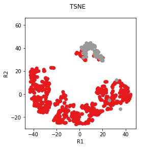

```python
# TSNE
R_TSNE = TSNE(n_components=2, perplexity=20, random_state=42).fit_transform(X)
scatterplot_2D(R_TSNE, 'TSNE', y)
```

# Classification

Finding the best classifier:

1. Logistic Regression
2. K Nearest Neighbors Classifier
3. Support Vector Machines Classification
4. Random Forest Classifier

# Logistic Regression

```python
# train model
lr = LogisticRegression(solver='lbfgs', max_iter=1000)
lr.fit(X_train, y_train)
y_pred = lr.predict(X_test)

# TSNE - visualize accuracy of model
R_TSNE = TSNE(n_components=2, perplexity=20, random_state=42).fit_transform(X_test)
scatterplot_2D(R_TSNE, 'y_test', y_test)
```

[output not shown]

```
Accuracy: 0.98 (+/- 0.02)
```

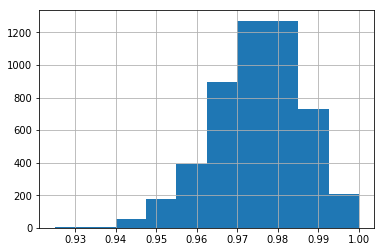

```python
# cross validate to evaluate model
scores = cross_val_score(lr, X, y, cv=cv, scoring='accuracy')

pd.Series(scores).hist()
print("Accuracy: %0.2f (+/- %0.2f)" % (scores.mean(), scores.std() * 2))
```

# K-Nearest Neighbors Classifier

```python
# train model
knn = KNeighborsClassifier()
knn.fit(X_train, y_train)
y_pred = knn.predict(X_test)

# TSNE - visualize accuracy of model
R_TSNE = TSNE(n_components=2, perplexity=20, random_state=42).fit_transform(X_test)
scatterplot_2D(R_TSNE, 'y_test', y_test)
```

[output not shown]

```
Accuracy: 0.98 (+/- 0.02)
```

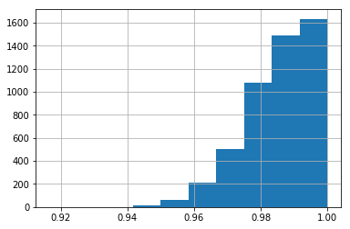

```python
# cross validate to evaluate model
scores = cross_val_score(knn, X, y, cv=cv, scoring='accuracy')

pd.Series(scores).hist()
print("Accuracy: %0.2f (+/- %0.2f)" % (scores.mean(), scores.std() * 2))
```

# Support Vector Machine

```python
# train model
svc = SVC(gamma='auto')
svc.fit(X_train, y_train)
y_pred = svc.predict(X_test)

# TSNE - visualize accuracy of model
R_TSNE = TSNE(n_components=2, perplexity=20, random_state=42).fit_transform(X_test)
scatterplot_2D(R_TSNE, 'y_test', y_test)
```

[output not shown]

```
Accuracy: 0.98 (+/- 0.02)
```

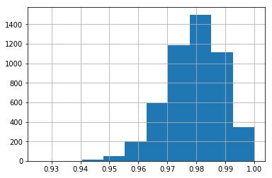

```python
# cross validate to evaluate model
scores = cross_val_score(svc, X, y, cv=cv, scoring='accuracy')

pd.Series(scores).hist()
print("Accuracy: %0.2f (+/- %0.2f)" % (scores.mean(), scores.std() * 2))
```

# Random Forest Classifier

```python
# train model
rf = RandomForestClassifier(n_estimators=100)
rf.fit(X_train, y_train)
y_pred = rf.predict(X_test)

# TSNE - visualize accuracy of model
R_TSNE = TSNE(n_components=2, perplexity=20, random_state=42).fit_transform(X_test)
scatterplot_2D(R_TSNE, 'y_test', y_test)
```

[output not shown]

```
Accuracy: 0.98 (+/- 0.02)
```

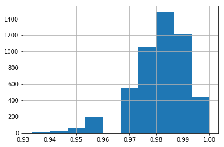

```python
# cross validate to evaluate model
scores = cross_val_score(rf, X, y, cv=cv, scoring='accuracy')

pd.Series(scores).hist()
print("Accuracy: %0.2f (+/- %0.2f)" % (scores.mean(), scores.std() * 2))
```

# Conclusions from RNA-Seq Classification Tumor/Normal

1. Emily crushed it
2. Possibly overfit tho

# Integration of RNA-Seq data with the Clinical Data

### The plan: combine Principle components of encoded clinical data with normalized principle components of RNA-Seq data, and then cluster with T-SNE

```python
# normalize data
normalized_tumor_RNA_seq = normalize(whole_patient.RNA_seq, axis = 0)
whole_patient.RNA_seq = pd.DataFrame(normalized_tumor_RNA_seq, columns=whole_patient.RNA_seq.columns, index=whole_patient.RNA_seq.index)
```

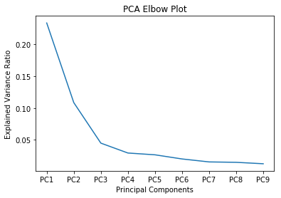

```python
# PCA
pca = PCA(n_components = 9)
pca.fit(whole_patient.RNA_seq)
variance = pca.explained_variance_ratio_
PC = ['PC1', 'PC2', 'PC3', 'PC4', 'PC5', 'PC6', 'PC7', 'PC8', 'PC9']

#PCA Elbow Plot
sb.lineplot(PC, variance)
plt.title("PCA Elbow Plot")
plt.xlabel("Principal Components")
plt.ylabel("Explained Variance Ratio")
plt.show()
# elbow is at PC5
```

```python
# Make df of RNA seq PCs
pca = PCA(n_components = 5)
pca_of_RNA = pca.fit(whole_patient.RNA_seq).transform(whole_patient.RNA_seq)

RNA_PCA = pd.DataFrame()
RNA_PCA['RNA-PC1'] = pca_of_RNA[:,0]
RNA_PCA['RNA-PC2'] = pca_of_RNA[:,1]
RNA_PCA['RNA-PC3'] = pca_of_RNA[:,2]
RNA_PCA['RNA-PC4'] = pca_of_RNA[:,3]
RNA_PCA['RNA-PC5'] = pca_of_RNA[:,4]
RNA_PCA.index = whole_patient.RNA_seq.index
```

```python
whole_patient_PCA = pd.DataFrame.join(clinical_PCA, RNA_PCA)
whole_patient_PCA = whole_patient_PCA.dropna()
```

```python
# Create numpy array of each row in the dataset
tsne_list = []
for x in range(len(whole_patient_PCA.index)):
    row = whole_patient_PCA.iloc[x,:]
    tsne_list.append(row)
tsne_list = np.array(tsne_list)

# Reduce dimensionality with TSNE
from sklearn.manifold import TSNE
tsne_transformed = TSNE(n_components=3, verbose = 1, perplexity = 25, n_iter = 1000, learning_rate = 50, random_state=1).fit_transform(tsne_list)
# T-SNE was improved by toggling the perplexity, the learning rate, and n_iter

# Create a column for each TSNE component and add it to the dataframe
whole_patient_PCA['tsne-one'] = tsne_transformed[:,0]
whole_patient_PCA['tsne-two'] = tsne_transformed[:,1]
whole_patient_PCA['tsne-three'] = tsne_transformed[:,2]
```

```
[t-SNE] Computing 76 nearest neighbors...
[t-SNE] Indexed 527 samples in 0.000s...
[t-SNE] Computed neighbors for 527 samples in 0.012s...
[t-SNE] Computed conditional probabilities for sample 527 / 527
[t-SNE] Mean sigma: 0.403020
[t-SNE] KL divergence after 250 iterations with early exaggeration: 56.641731
[t-SNE] KL divergence after 1000 iterations: 0.375972
```

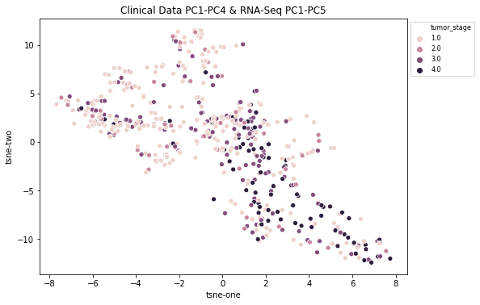

```python
# Plot using TSNE scatterplot
plt.figure(figsize=(10,7))
sb.scatterplot(x='tsne-one', y='tsne-two', data=whole_patient_PCA, hue=whole_patient.target)
plt.title('Clinical Data PC1-PC4 & RNA-Seq PC1-PC5')
plt.legend(loc='upper left', prop={'size':8}, bbox_to_anchor=(1,1))
plt.tight_layout(pad=7)
plt.show()
```

# Classification of Tumor Stage from Clinical and RNA-Seq Data

```python
# Use the get_tumor_stages function to get target labels for data
tumor_stage_dict = get_tumor_stages(whole_patient)
pts_with_both = list(whole_patient_PCA.index)
whole_patient_PCA.target = []
for x in pts_with_both:
    whole_patient_PCA.target.append(tumor_stage_dict[x])
```

```python
# Convert Index to integers for ML
whole_patient_PCA.index = range(len(whole_patient_PCA.index))
```

```python
# Define data and target
X = whole_patient_PCA
y = np.array(whole_patient_PCA.target)

# stratify data to train/test model
X_train, X_test, y_train, y_test = train_test_split(X, y, test_size = 0.2, stratify=y, random_state=42)

# define cross validation method
cv = RepeatedStratifiedKFold(n_splits=5,n_repeats=1000, random_state=42)
```

# Logistic Regression

```
Accuracy: 0.54 (+/- 0.06)
```

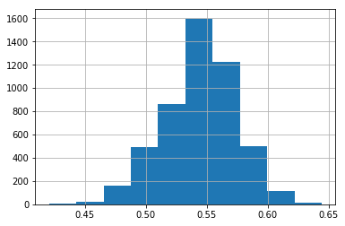

```python
# train model
lr = LogisticRegression(solver='lbfgs', max_iter=1000)
lr.fit(X_train, y_train)
y_pred = lr.predict(X_test)

# cross validate to evaluate model
scores = cross_val_score(lr, X, y, cv=cv, scoring='accuracy')

pd.Series(scores).hist()
print("Accuracy: %0.2f (+/- %0.2f)" % (scores.mean(), scores.std() * 2))
```

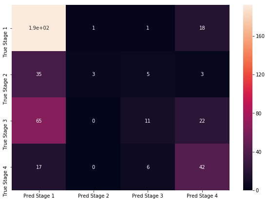

```python
## Create confusion matrix for Random Forest
lr_Y_predicted = lr.predict(X_train)
array = confusion_matrix(y_train, lr_Y_predicted)
df_cm = pd.DataFrame(array, index = [i for i in ['True Stage 1', ' True Stage 2', 'True Stage 3', 'True Stage 4']],
                  columns = [i for i in ['Pred Stage 1', 'Pred Stage 2', 'Pred Stage 3', 'Pred Stage 4']])
plt.figure(figsize = (10,7))
sb.heatmap(df_cm, annot=True)
```

# K-Nearest Neighbors

```
Accuracy: 0.46 (+/- 0.07)
```

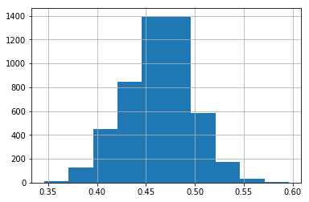

```python
# train model
knn = KNeighborsClassifier()
knn.fit(X_train, y_train)
y_pred = knn.predict(X_test)

# cross validate to evaluate model
scores = cross_val_score(knn, X, y, cv=cv, scoring='accuracy')

pd.Series(scores).hist()
print("Accuracy: %0.2f (+/- %0.2f)" % (scores.mean(), scores.std() * 2))
```

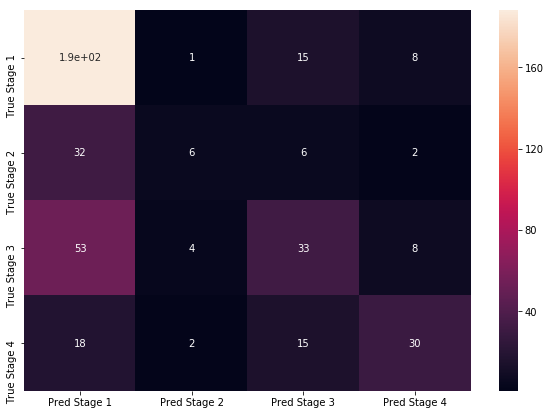

```python
## Create confusion matrix for KNN
knn_Y_predicted = knn.predict(X_train)
array = confusion_matrix(y_train, knn_Y_predicted)
df_cm = pd.DataFrame(array, index = [i for i in ['True Stage 1', ' True Stage 2', 'True Stage 3', 'True Stage 4']],
                  columns = [i for i in ['Pred Stage 1', 'Pred Stage 2', 'Pred Stage 3', 'Pred Stage 4']])
plt.figure(figsize = (10,7))
sb.heatmap(df_cm, annot=True)
```

# Support Vector Machine

```
Accuracy: 0.52 (+/- 0.06)
```

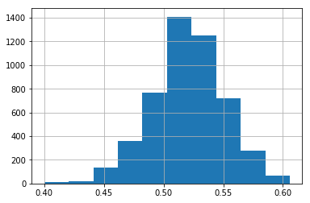

```python
# train model
svc = SVC(gamma='auto')
svc.fit(X_train, y_train)
y_pred = svc.predict(X_test)

# cross validate to evaluate model
scores = cross_val_score(svc, X, y, cv=cv, scoring='accuracy')

pd.Series(scores).hist()
print("Accuracy: %0.2f (+/- %0.2f)" % (scores.mean(), scores.std() * 2))
```

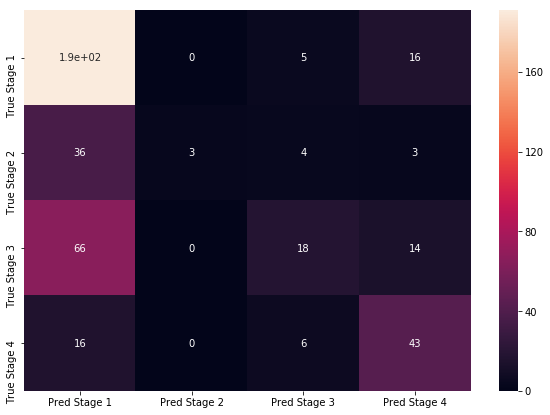

```python
## Create confusion matrix for Support Vector Machine
svc_Y_predicted = svc.predict(X_train)
array = confusion_matrix(y_train, svc_Y_predicted)
df_cm = pd.DataFrame(array, index = [i for i in ['True Stage 1', ' True Stage 2', 'True Stage 3', 'True Stage 4']],
                  columns = [i for i in ['Pred Stage 1', 'Pred Stage 2', 'Pred Stage 3', 'Pred Stage 4']])
plt.figure(figsize = (10,7))
sb.heatmap(df_cm, annot=True)
```

# Random Forest Classifier

```
Accuracy: 0.51 (+/- 0.07)
```

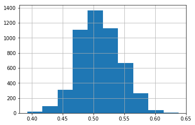

```python
# train model
rf = RandomForestClassifier(n_estimators=100)
rf.fit(X_train, y_train)
y_pred = rf.predict(X_test)

# cross validate to evaluate model
scores = cross_val_score(rf, X, y, cv=cv, scoring='accuracy')

pd.Series(scores).hist()
print("Accuracy: %0.2f (+/- %0.2f)" % (scores.mean(), scores.std() * 2))
```

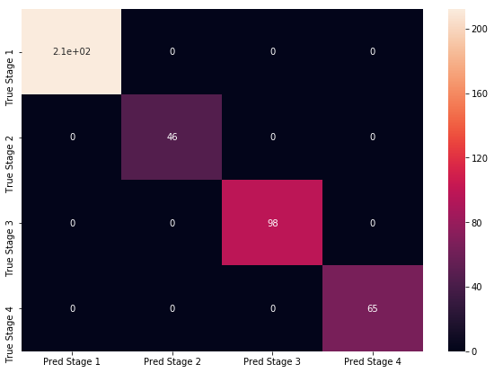

```python
## Create confusion matrix for Random Forest
rf_Y_predicted = rf.predict(X_train)
array = confusion_matrix(y_train, rf_Y_predicted)
df_cm = pd.DataFrame(array, index = [i for i in ['True Stage 1', ' True Stage 2', 'True Stage 3', 'True Stage 4']],
                  columns = [i for i in ['Pred Stage 1', 'Pred Stage 2', 'Pred Stage 3', 'Pred Stage 4']])
plt.figure(figsize = (10,7))
sb.heatmap(df_cm, annot=True)
```

### wha?

# Future work

# Convolutional Autoencoder

[figure not shown]

The current plan is to take the latent vector, h, for each image from each of the patients, and to integrate it much the same way as the RNA-Seq data was with the clinical data

1. The dataset also includes miRNA-Seq data. Analysis of this data in addition to the clinical data may yield stronger clustering for tumor stage.
2. Check for over-fitting of tumor v normal classifiers, and improve performance of tumor stage classifiers.
3. Integrating the image analysis data using a convolutional autoencoder.